# Investigating Air Quality with BigRQuery

Kevin Ushey

September 12, 2017

# Getting Started with BigRQuery

In this R Notebook, we’ll use the `bigrquery` package to explore some of the public air quality datasets available on the Google Cloud Platform. These datasets are provided by the US Environmental Protection Agency.

## Credentials + Project Setup

You might need to teach RStudio + `bigrquery` how to talk to BigQuery. In my case, I set up an access token as discussed in https://developers.google.com/identity/protocols/application-default-credentials?hl=en_US; the credentials are copied on the system (as `credentials.json`).

```r
library(bigrquery)

# set project name
project <- "perfect-lantern-179621"

# set up credentials
credentials <- readr::read_file("credentials.json")
set_service_token(credentials)
```

## First Steps

First, let’s try running some raw SQL with `query_exec()` to confirm that we’ve got our environment set up as expected. We’ll try looking at the first 20 rows of the `air_quality_annual_summary` data set, from the `epa_historical_air_quality` database. (See https://bigquery.cloud.google.com/dataset/bigquery-public-data:epa_historical_air_quality for more details on this dataset.)

```r
library(bigrquery)

# generate our SQL query (as an R string)
sql <- "
  SELECT
    *
  FROM
    [bigquery-public-data:epa_historical_air_quality.air_quality_annual_summary]
  LIMIT
    20
"

# run it with 'query_exec()'
query_exec(sql, project = project)
```

```
## 0 bytes processed
```

```
##    state_code county_code site_num parameter_code poc latitude  longitude
## 1          25         021     1001          42401   1 42.21287  -71.33506
## 2          30         013     1026          88101   1 47.50218 -111.27970
## 3          48         167     0014          43819   1 29.26332  -94.85657
## 4          48         273     0314          61106   1 27.42698  -97.29869
## 5          26         163     1005          43552   2 42.28945  -83.15344
## 6          08         067     0004          81102   1 37.27780 -107.88093
## 7          27         137     7549          45810   1 46.77107  -92.11732
## 8          05         119     1008          68101   2 34.68134  -92.32870
## 9          80         002     0003          42602   1 32.49839 -116.97752
## 10         48         203     0002          43518   1 32.66899  -94.16746
## 11         33         007     4002          88152   1 44.30813  -71.21764
## 12         06         071     0306          61102   1 34.51001 -117.33143
## 13         36         061     0128          68103   1 40.73000  -73.98400
## 14         48         029     0036          62101   1 29.50472  -98.53889
```

[output cut: 405 more lines]

`query_exec()` is handy when you want to execute a one-off query, or a set of SQL that you’ve either defined inline or perhaps as part of a separate script (e.g. a `.sql` file).

## Using DBI

The `bigrquery` package also provides a DBI driver, which makes it possible to talk to Google’s BigQuery using the `DBI` generics you might already be familiar with.

```r
library(DBI)

# construct a DBI connection using bigrquery's DBI driver to the
# 'epa_historical_air_quality' database
conn <- DBI::dbConnect(
  bigrquery::dbi_driver(),
  project = "bigquery-public-data",
  dataset = "epa_historical_air_quality",
  billing = project
)

# list the tables available in this database
DBI::dbListTables(conn)
```

```
##  [1] "air_quality_annual_summary"     "co_daily_summary"
##  [3] "co_hourly_summary"              "hap_daily_summary"
##  [5] "hap_hourly_summary"             "lead_daily_summary"
##  [7] "no2_daily_summary"              "no2_hourly_summary"
##  [9] "nonoxnoy_daily_summary"         "nonoxnoy_hourly_summary"
## [11] "o3_daily_summary"               "o3_hourly_summary"
## [13] "pm10_daily_summary"             "pm10_hourly_summary"
## [15] "pm25_frm_daily_summary"         "pm25_frm_hourly_summary"
## [17] "pm25_nonfrm_daily_summary"      "pm25_nonfrm_hourly_summary"
## [19] "pm25_speciation_daily_summary"  "pm25_speciation_hourly_summary"
## [21] "pressure_daily_summary"         "pressure_hourly_summary"
## [23] "rh_and_dp_daily_summary"        "rh_and_dp_hourly_summary"
## [25] "so2_daily_summary"              "so2_hourly_summary"
## [27] "temperature_daily_summary"      "temperature_hourly_summary"
## [29] "voc_daily_summary"              "voc_hourly_summary"
## [31] "wind_daily_summary"             "wind_hourly_summary"
```

Great! Let’s try running the same query we used above. Now that we’ve established a connection directly to the `epa_historical_air_quality` database, it’s no longer necessary to specifiy the full `[database:table]` name in our SQL statement – we can reference the `air_quality_annual_summary` table directly.

```r
# run a SQL statement directly
sql <- "SELECT * FROM air_quality_annual_summary LIMIT 20"
DBI::dbGetQuery(conn, sql)
```

```
## 0 bytes processed
```

```
##    state_code county_code site_num parameter_code poc latitude  longitude
## 1          25         021     1001          42401   1 42.21287  -71.33506
## 2          30         013     1026          88101   1 47.50218 -111.27970
## 3          48         167     0014          43819   1 29.26332  -94.85657
## 4          48         273     0314          61106   1 27.42698  -97.29869
## 5          26         163     1005          43552   2 42.28945  -83.15344
## 6          08         067     0004          81102   1 37.27780 -107.88093
## 7          27         137     7549          45810   1 46.77107  -92.11732
## 8          05         119     1008          68101   2 34.68134  -92.32870
## 9          80         002     0003          42602   1 32.49839 -116.97752
## 10         48         203     0002          43518   1 32.66899  -94.16746
## 11         33         007     4002          88152   1 44.30813  -71.21764
## 12         06         071     0306          61102   1 34.51001 -117.33143
## 13         36         061     0128          68103   1 40.73000  -73.98400
## 14         48         029     0036          62101   1 29.50472  -98.53889
```

[output cut: 405 more lines]

In fact, once we have this DBI connection available, we can write a SQL code block directly to construct and execute a query.

```sql
SELECT * FROM air_quality_annual_summary LIMIT 20
```

Displaying records 1 - 10

| state_code | county_code | site_num | parameter_code | poc | latitude | longitude | datum | parameter_name | sample_duration | pollutant_standard | metric_used | method_name | year | units_of_measure | event_type | observation_count | observation_percent | completeness_indicator | valid_day_count | required_day_count | exceptional_data_count | null_data_count | primary_exceedance_count | secondary_exceedance_count | certification_indicator | num_obs_below_mdl | arithmetic_mean | arithmetic_standard_dev | first_max_value | … |
| --- | --- | --- | --- | --- | --- | --- | --- | --- | --- | --- | --- | --- | --- | --- | --- | --- | --- | --- | --- | --- | --- | --- | --- | --- | --- | --- | --- | --- | --- | --- |
| 25 | 021 | 1001 | 42401 | 1 | 42.21287 | -71.33506 | WGS84 | Sulfur dioxide | 24-HR BLK AVG | SO2 24-hour 1971 | Daily Average of observed values |  | 1986 | Parts per billion | No Events | 41 | 11 | N | 41 | 365 | 0 | 0 | 0 | NA | Certification not required | 0 | 9.317073 | 4.259572 | 20.90 | … |
| 30 | 013 | 1026 | 88101 | 1 | 47.50218 | -111.27970 | WGS84 | PM2.5 - Local Conditions | 24 HOUR | PM25 24-hour 2006 | Daily Mean | BGI Model PQ200 PM2.5 Sampler w/WINS - GRAVIMETRIC | 2001 | Micrograms/cubic meter (LC) | No Events | 113 | 93 | Y | 113 | 122 | 0 | 9 | 0 | 0 | Certified | 0 | 5.420354 | 4.292376 | 33.00 | … |
| 48 | 167 | 0014 | 43819 | 1 | 29.26332 | -94.85657 | WGS84 | Bromomethane | 24 HOUR |  | Observed Values | Passivated Canister - Cryogenic Preconcentration GC/MS | 2006 | Parts per billion Carbon | No Events | 57 | 93 | Y | 57 | 61 | 0 | 0 | NA | NA | Requested but denied | 0 | 0.010000 | 0.000000 | 0.01 | … |
| 48 | 273 | 0314 | 61106 | 1 | 27.42698 | -97.29869 | WGS84 | Std Dev Hz Wind Direction | 1 HOUR |  | Observed Values | INSTRUMENTAL - ARITHMETIC STANDARD DEVIATION | 2016 | Degrees Compass | No Events | 8092 | 92 | Y | 331 | 366 | 0 | 676 | NA | NA | Certification not required | 0 | 10.149580 | 7.512767 | 77.70 | … |
| 26 | 163 | 1005 | 43552 | 2 | 42.28945 | -83.15344 | WGS84 | Methyl ethyl ketone | 24 HOUR |  | Observed Values | 6L Subatm SS Canister - Entech Precon GC/MS | 2015 | Parts per billion Carbon | No Events | 10 | 17 | N | 10 | 60 | 0 | 1 | NA | NA | Certification not required | 0 | 0.900000 | 0.815026 | 2.44 | … |
| 08 | 067 | 0004 | 81102 | 1 | 37.27780 | -107.88093 | WGS84 | PM10 Total 0-10um STP | 24 HOUR | PM10 24-hour 2006 | Daily Mean | HI-VOL SA/GMW-1200 - GRAVIMETRIC | 2003 | Micrograms/cubic meter (25 C) | Events Inclucded | 102 | 84 | N | 102 | 121 | 1 | 19 | 0 | 0 | Certified | 0 | 21.382353 | 10.870110 | 97.00 | … |
| 27 | 137 | 7549 | 45810 | 1 | 46.77107 | -92.11732 | WGS84 | 1,2,4-Trichlorobenzene | 24 HOUR |  | Observed Values | SS-CANISTER-PRESSURIZED - CAPILLARY GC ITD MASS SPECTRO | 2011 | Parts per billion Carbon | No Events | 47 | 77 | N | 47 | 61 | 0 | 8 | NA | NA | Certification not required | 0 | 0.000000 | 0.000000 | 0.00 | … |
| 05 | 119 | 1008 | 68101 | 2 | 34.68134 | -92.32870 | WGS84 | Sample Flow Rate- CV | 24 HOUR |  | Observed Values | R & P Model 2025 PM2.5 Sequent - Calculation | 2001 | Percent | No Events | 53 | 87 | N | 53 | 61 | 0 | 0 | NA | NA | Certification not required | 0 | 0.373585 | 0.148260 | 0.60 | … |
| 80 | 002 | 0003 | 42602 | 1 | 32.49839 | -116.97752 | WGS84 | Nitrogen dioxide (NO2) | 1 HOUR | NO2 Annual 1971 | Observed values | INSTRUMENTAL - CHEMILUMINESCENCE | 1997 | Parts per billion | No Events | 7507 | 86 | Y | 322 | 365 | 0 | 1253 | NA | NA | Certification not required | 0 | 23.169708 | 16.610207 | 194.00 | … |
| 48 | 203 | 0002 | 43518 | 1 | 32.66899 | -94.16746 | WGS84 | Valeraldehyde | 24 HOUR |  | Observed Values | ATEC 2400 W/WATERS SILICA DNPH - Liquid Chromatography w/diode array detection | 2010 | Parts per billion Carbon | No Events | 59 | 97 | Y | 58 | 61 | 0 | 0 | NA | NA | Certification not required | 0 | 0.051525 | 0.047044 | 0.16 | … |

## Using dplyr

The `dplyr` package provides a flexible grammar for data manipulation. It has three main goals:

- Identify the most important data manipulation verbs and make them easy to use from R.
- Provide blazing fast performance for in-memory data by writing key pieces in C++ (using Rcpp)
- Use the same interface to work with data no matter where it’s stored, whether in a data frame, a data table or database.

This implies that the same code you might use to interact with an in-memory R data.frame will look very similar to the code you might write to access a table stored in a SQL database. Let’s get `dplyr` talking to Google BigQuery:

```r
library(dplyr)
library(dbplyr)
```

```r
# construct a 'src': this is the connection object that dplyr uses
# to communicate with Google BigQuery
src <- bigrquery::src_bigquery(
  project = "bigquery-public-data",
  dataset = "epa_historical_air_quality",
  billing = project
)

# generate a reference to the 'air_quality_annual_summary' table
aqas <- tbl(src, "air_quality_annual_summary")

aqas
```

```
## 1.0 gigabytes processed
```

```
## # Source:   table<air_quality_annual_summary> [?? x 55]
## # Database: BigQueryConnection
##    state_code county_code site_num parameter_code   poc latitude
##         <chr>       <chr>    <chr>          <int> <int>    <dbl>
##  1         26         163     1005          43552     2 42.28945
##  2         48         203     0002          43518     1 32.66899
##  3         27         137     7549          45810     1 46.77107
##  4         48         167     0014          43819     1 29.26332
##  5         48         273     0314          61106     1 27.42698
##  6         05         119     1008          68101     2 34.68134
##  7         80         002     0003          42602     1 32.49839
##  8         25         021     1001          42401     1 42.21287
##  9         30         013     1026          88101     1 47.50218
## 10         08         067     0004          81102     1 37.27780
## # ... with more rows, and 49 more variables: longitude <dbl>, datum <chr>,
## #   parameter_name <chr>, sample_duration <chr>, pollutant_standard <chr>,
## #   metric_used <chr>, method_name <chr>, year <int>,
## #   units_of_measure <chr>, event_type <chr>, observation_count <int>,
## #   observation_percent <dbl>, completeness_indicator <chr>,
## #   valid_day_count <int>, required_day_count <int>,
## #   exceptional_data_count <int>, null_data_count <int>,
## #   primary_exceedance_count <int>, secondary_exceedance_count <int>,
## #   certification_indicator <chr>, num_obs_below_mdl <int>,
## #   arithmetic_mean <dbl>, arithmetic_standard_dev <dbl>,
## #   first_max_value <dbl>, first_max_datetime <dttm>,
## #   second_max_value <dbl>, second_max_datetime <dttm>,
## #   third_max_value <dbl>, third_max_datetime <dttm>,
## #   fourth_max_value <dbl>, fourth_max_datetime <dttm>,
## #   first_max_non_overlapping_value <dbl>, first_no_max_datetime <dttm>,
## #   second_max_non_overlapping_value <dbl>, second_no_max_datetime <dttm>,
## #   ninety_nine_percentile <dbl>, ninety_eight_percentile <dbl>,
## #   ninety_five_percentile <dbl>, ninety_percentile <dbl>,
## #   seventy_five_percentile <dbl>, fifty_percentile <dbl>,
## #   ten_percentile <dbl>, local_site_name <chr>, address <chr>,
## #   state_name <chr>, county_name <chr>, city_name <chr>, cbsa_name <chr>,
## #   date_of_last_change <date>
```

Awesome! Now, let’s try using `dplyr` to answer the question, “what was the average air quality in each year, by state?”. In the context of SQL databases, you can think of `dplyr` as a generator for SQL select statements.

```r
# construct our query using the dplyr interface
query <- aqas %>%
  select(state_name, year, units_of_measure, arithmetic_mean) %>%
  group_by(state_name, year) %>%
  summarize(avg = mean(arithmetic_mean))

# inspect the SQL actually generated here
sql_render(query)
```

```
## <SQL> SELECT `state_name`, `year`, AVG(`arithmetic_mean`) AS `avg`
## FROM (SELECT `state_name` AS `state_name`, `year` AS `year`, `units_of_measure` AS `units_of_measure`, `arithmetic_mean` AS `arithmetic_mean`
## FROM `air_quality_annual_summary`) `zkachiczec`
## GROUP BY `state_name`, `year`
```

Now, let’s try running that query:

```r
# use 'collect()' to execute the query, and retrieve
# the results as an R data.frame
quality <- collect(query)
```

```
## 52.0 megabytes processed
```

```r
quality
```

```
## # A tibble: 2,060 x 3
## # Groups:   state_name [56]
##              state_name  year      avg
##                   <chr> <int>    <dbl>
##  1 District Of Columbia  1980 78.96545
##  2       South Carolina  1980 14.72178
##  3           Washington  1980 22.68435
##  4                Maine  1980 27.36110
##  5              Alabama  1980 45.20413
##  6               Oregon  1980 64.07693
##  7                 Guam  1980 16.92663
##  8            Louisiana  1980 15.51748
##  9              Florida  1980 26.60139
## 10           New Mexico  1980 33.45153
## # ... with 2,050 more rows
```

```r
pm10 <- tbl(src, "pm10_daily_summary")
pm10
```

```
## 1.3 gigabytes processed
```

```
## # Source:   table<pm10_daily_summary> [?? x 29]
## # Database: BigQueryConnection
##    state_code county_code site_num parameter_code   poc latitude
##         <chr>       <chr>    <chr>          <int> <int>    <dbl>
##  1         06         011     0007          81102     1 39.02122
##  2         53         011     0013          81102     1 45.64833
##  3         32         003     0298          81102     1 36.04874
##  4         21         145     1024          81102     1 37.05822
##  5         06         027     1003          81102     1 36.48782
##  6         15         003     1001          81102     1 21.30758
##  7         04         013     0013          81102     5 33.40528
##  8         04         013     9997          81102     3 33.50383
##  9         17         031     1016          81102     4 41.80118
## 10         08         031     0002          81102     3 39.75118
## # ... with more rows, and 23 more variables: longitude <dbl>, datum <chr>,
## #   parameter_name <chr>, sample_duration <chr>, pollutant_standard <chr>,
## #   date_local <date>, units_of_measure <chr>, event_type <chr>,
## #   observation_count <int>, observation_percent <dbl>,
## #   arithmetic_mean <dbl>, first_max_value <dbl>, first_max_hour <int>,
## #   aqi <int>, method_code <int>, method_name <chr>,
## #   local_site_name <chr>, address <chr>, state_name <chr>,
## #   county_name <chr>, city_name <chr>, cbsa_name <chr>,
## #   date_of_last_change <date>
```

Let’s look at the yearly average PM10.

```r
avg <- pm10 %>%
  select(state_name, arithmetic_mean, date_local) %>%
  mutate(year = extract(year %from% date_local)) %>%
  group_by(state_name, year) %>%
  summarize(mean = mean(arithmetic_mean)) %>%
  arrange(state_name, year) %>%
  collect()
```

```
## 102.0 megabytes processed
```

And let’s take a look at the trends over time. We’ll use the `ggplot2` package to visualize.

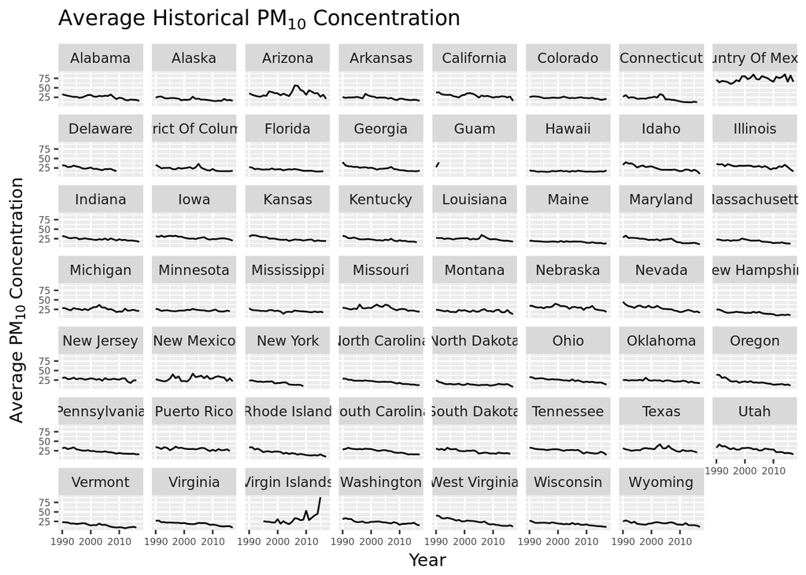

```r
library(ggplot2)

ggplot(avg, aes(x = year, y = mean)) +
  geom_line() +
  facet_wrap(~ state_name) +
  labs(x = "Year", y = expression(Average ~ PM[10] ~ Concentration)) +
  ggtitle(expression(Average ~ Historical ~ PM[10] ~ Concentration)) +
  theme(
    axis.text.x = element_text(size = 6),
    axis.text.y = element_text(size = 6)
  )
```

Cool! Let’s do one last cool thing – we’ll use the `leaflet` package to visualize the last hour of Air Quality data, as provided by [OpenAQ](https://openaq.org/) and made available in the `global_air_quality` dataset.

```r
src <- bigrquery::src_bigquery(
  project = "bigquery-public-data",
  dataset = "openaq",
  billing = project
)

tbl <- tbl(src, "global_air_quality")
tbl
```

```
## 10.0 megabytes processed
```

```
## # Source:   table<global_air_quality> [?? x 11]
## # Database: BigQueryConnection
##                location                                city country
##                   <chr>                               <chr>   <chr>
##  1 Fontana - Arrow High    Riverside-San Bernardino-Ontario      US
##  2      Cool (Seasonal) Sacramento--Arden-Arcade--Roseville      US
##  3          Salinas AMS                             Salinas      US
##  4 Minneapolis-Near Roa    Minneapolis-St. Paul-Bloomington      US
##  5              Larwill                             WHITLEY      US
##  6   Greiz Mollbergstr.                       Peter Reischl      DE
##  7 Palacio De Congresos                             Granada      ES
##  8   ST ETIENNE ROND PT                     AIR RHONE ALPES      FR
##  9              ZooPark                           Hyderabad      IN
## 10          IGI Airport                               Delhi      IN
## # ... with more rows, and 8 more variables: pollutant <chr>, value <dbl>,
## #   timestamp <dttm>, unit <chr>, source_name <chr>, latitude <dbl>,
## #   longitude <dbl>, averaged_over_in_hours <dbl>
```

```r
library(leaflet)

# define our query and collect the data into R
pm25 <- tbl %>%
  filter(pollutant == "pm25", country == "US") %>%
  select(location, city, country, value, latitude, longitude, timestamp) %>%
  arrange(value) %>%
  collect()
```

```
## 10.0 megabytes processed
```

```r
# define a palette used for coloring points on our map
# we'll color based on the measured pm10 (higher is darker orange)
pal <- colorNumeric("Oranges", domain = pm25$value)

# format used for labels
fmt <- "[%s] %s, %s, %s: (%s)"

# construct our map
leaflet(pm25) %>%
  addTiles() %>%
  addCircleMarkers(
    lat = ~ latitude,
    lng = ~ longitude,
    color = ~ pal(value),
    label = ~ sprintf(fmt, timestamp, location, city, country, value),
    stroke = FALSE,
    fillOpacity = 0.6
  ) %>%
  addLegend(
    "bottomright",
    pal = pal,
    values = ~ value,
    title = "Latest Measured PM10"
  )
```

[interactive chart not shown]